# Convolutional Neural Networks

## Project: Write an Algorithm for Landmark Classification

### Transfer learning

In the previous notebook we have trained our own CNN and we got a certain performance. Let's see how hard it is to match that performance with transfer learning.

## Step 0: Setting up

[figure not shown]

The following cells make sure that your environment is setup correctly and check that your GPU is available and ready to go. You have to execute them every time you restart your notebook.

```python
# Install requirements
!pip install -r requirements.txt | grep -v "already satisfied"
```

[output not shown]

```python
from src.helpers import setup_env

# If running locally, this will download dataset (make sure you have at
# least 2 Gb of space on your hard drive)
setup_env()
```

```
GPU available
Dataset already downloaded. If you need to re-download, please delete the directory landmark_images
Reusing cached mean and std
```

## Step 1: Create transfer learning architecture

[figure not shown]

Open the file `src/transfer.py` and complete the `get_model_transfer_learning` function. When you are done, execute this test:

```python
!pytest -vv src/transfer.py
```

```
============================= test session starts ==============================
platform linux -- Python 3.7.10, pytest-7.1.1, pluggy-1.2.0 -- /usr/local/bin/python3.7
cachedir: .pytest_cache
rootdir: /root/udacity-landmark-classification
plugins: anyio-3.7.1
collected 1 item

src/transfer.py::test_get_model_transfer_learning PASSED                 [100%]

============================== 1 passed in 3.53s ===============================
```

## Step 2: Train, validation and test

[figure not shown]

Let's train our transfer learning model! Let's start defining the hyperparameters:

```python
batch_size = 64  # size of the minibatch for stochastic gradient descent (or Adam)
valid_size = 0.2  # fraction of the training data to reserve for validation
num_epochs = 50  # number of epochs for training
num_classes = 50  # number of classes. Do not change this
learning_rate = 0.001  # Learning rate for SGD (or Adam)
opt = 'adam'      # optimizer. 'sgd' or 'adam'
weight_decay = 0.001 # regularization. Increase this to combat overfitting
```

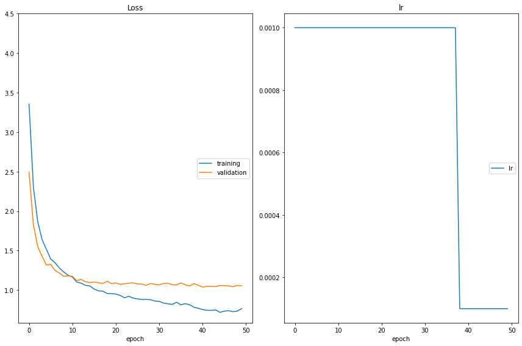

```python
from src.data import get_data_loaders
from src.optimization import get_optimizer, get_loss
from src.train import optimize
from src.transfer import get_model_transfer_learning

# Get a model using get_model_transfer_learning. Use one of the names reported here:
# https://pytorch.org/vision/0.10/models.html
# For example, if you want to load ResNet 18, use "resnet18"
# NOTE: use the hyperparameters defined in the previous cell, do NOT copy/paste the
# values
model_transfer = get_model_transfer_learning(model_name="resnet18", n_classes=num_classes)

# train the model
data_loaders = get_data_loaders(batch_size=batch_size)
optimizer = get_optimizer(
    model_transfer,
    learning_rate=learning_rate,
    optimizer=opt,
    weight_decay=weight_decay,
)
loss = get_loss()

optimize(
    data_loaders,
    model_transfer,
    optimizer,
    loss,
    n_epochs=num_epochs,
    save_path="checkpoints/model_transfer.pt",
    interactive_tracking=True
)
```

[figure not shown]

**Question:** Outline the steps you took to get to your final CNN architecture and your reasoning at each step. Describe why you think the architecture is suitable for the current problem.

[figure not shown]

**Answer:** I decided to use ResNet18 for the base of my model, since it performs fairly well on ImageNet and is not too large of a model. Also, since ResNet18 was trained for the ImageNet task, it is a good model to use for this landmark classificaiton task, since both ImageNet and this landmark task use images of natural scenes.

1. I decided to use ResNet18 for the base of my model because it introduced the concept of residual blocks, which enable the training of much deeper networks. Deeper architectures are capable of learning more complex features and patterns from data, which is advantageous for image classification tasks with diverse classes and variations.Besides, residual connections tend to mitigate the vanishing gradient problem that can occur in very deep networks.
2. Froze the parameters of the pre-trained convolutional layers by setting requires_grad = False.
3. Replaced the final fully connected layer (output layer) of the pre-trained model to match the number of classes in the current problem.
4. Used the adapted pre-trained model as the starting point and trained it on the new dataset (current problem).
5. Used weight_decay=0.001

Now play with the hyperparameters and see which performance you can get on the validation set. You should get at least 60% for a passing grade, but a good model choice and a good training strategy could get you up to 80% or so. Let's see how close you can get!

## Step 3: Test the Model

[figure not shown]

Try out your model on the test dataset of landmark images. Use the code cell below to calculate and print the test loss and accuracy. Ensure that your test accuracy is greater than 60% and matches more or less what you got on the validation set (otherwise you're overfitting!)

```python
import torch
from src.train import one_epoch_test
from src.transfer import get_model_transfer_learning

model_transfer = get_model_transfer_learning("resnet18", n_classes=num_classes)
# Load saved weights
model_transfer.load_state_dict(torch.load('checkpoints/model_transfer.pt'))

one_epoch_test(data_loaders['test'], model_transfer, loss)
```

```
Test Loss: 0.939961


Test Accuracy: 74% (933/1250)
```

```
0.9399605542421342
```

## Step 4: Export using torchscript

[figure not shown]

Now, just like we did with our original model, we export the best fit model using torchscript so that it can be used in our application:

```python
from src.predictor import Predictor
from src.helpers import compute_mean_and_std

# First let's get the class names from our data loaders
class_names = data_loaders["train"].dataset.classes

# Then let's move the model_transfer to the CPU
# (we don't need GPU for inference)
model_transfer = model_transfer.cpu()
# Let's make sure we use the right weights by loading the
# best weights we have found during training
# NOTE: remember to use map_location='cpu' so the weights
# are loaded on the CPU (and not the GPU)
model_transfer.load_state_dict(
    torch.load("checkpoints/model_transfer.pt", map_location="cpu")
)

# Let's wrap our model using the predictor class
mean, std = compute_mean_and_std()
predictor = Predictor(model_transfer, class_names, mean, std).cpu()

# Export using torch.jit.script
scripted_predictor = torch.jit.script(predictor)
scripted_predictor.save("checkpoints/transfer_exported.pt")
```

```
Reusing cached mean and std
```

```
Accuracy: 0.7576
```

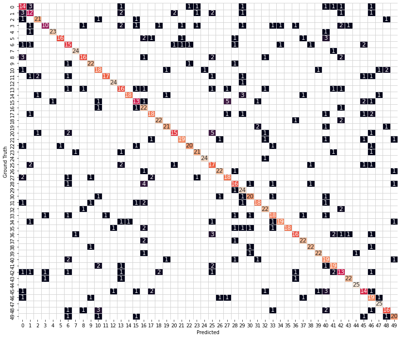

```python
import torch
from src.predictor import predictor_test
from src.helpers import plot_confusion_matrix

model_reloaded = torch.jit.load("checkpoints/transfer_exported.pt")

pred, truth = predictor_test(data_loaders['test'], model_reloaded)

plot_confusion_matrix(pred, truth)
```